# Hands-on part 3 - Data wrangling

November 2nd 2018

## Citations

```r
citation(package = "dplyr")
```

```
##
##
##   Hadley Wickham, Romain François, Lionel Henry and Kirill Müller
##   (2018). dplyr: A Grammar of Data Manipulation. R package version
##   0.7.6. https://CRAN.R-project.org/package=dplyr
##
## A BibTeX entry for LaTeX users is
##
##   @Manual{,
##     title = {dplyr: A Grammar of Data Manipulation},
##     author = {Hadley Wickham and Romain François and Lionel Henry and Kirill Müller},
##     year = {2018},
##     note = {R package version 0.7.6},
##     url = {https://CRAN.R-project.org/package=dplyr},
##   }
```

## Packages

```r
library(dslabs)
library(tidyverse)
```

## Case Data

- Pertussis outbreaks from The World Health Organization
- http://data.euro.who.int/cisid/?TabID=463987
- http://ecdc.europa.eu/sites/portal/files/documents/Pertussis%20AER.pdf
- The data used in this presentation has been constructed from the interactive database tool hosted at: http://data.euro.who.int/cisid/
- A selection was made for all available countries and all available years, for the number of cases reported to the WHO for Whooping Cough - pertussis infections.
- The file is avaialble in `./data/CISID_pertussis_10082018.csv`
- The values included here in the dataset are the total reported cases, per country per year.
- At the start of the file there are remarks and metadata indicated by `#`

## Inspect the file with a system command from the `Terminal`

```bash
head -20 ~/surfR/data/CISID_pertussis_10082018.csv
```

```
## # Created on 10/08/2018 11:37:45,,,,,,,,,,,,,,,,,,,,,,,,,,,,,,,,,,,,,,,,
## # ,,,,,,,,,,,,,,,,,,,,,,,,,,,,,,,,,,,,,,,,
## #,,,,,,,,,,,,,,,,,,,,,,,,,,,,,,,,,,,,,,,,
## # Indicator Comment:,,,,,,,,,,,,,,,,,,,,,,,,,,,,,,,,,,,,,,,,
## # Country , Year , Comment,,,,,,,,,,,,,,,,,,,,,,,,,,,,,,,,,,,,,,
## #All,All,Blank cells indicate that data is either unavailable and/or has not yet been #reported to WHO,,,,,,,,,,,,,,,,,,,,,,,,,,,,,,,,,,,,,,
## #Switzerland,2004,Estimates from Sentinel surveillance,,,,,,,,,,,,,,,,,,,,,,,,,,,,,,,,,,,#,,,
## #
## #
## #
##  , ,1980,1981,1982,1983,1984,1985,1986,1987,1988,1989,1990,1991,1992,1993,1994,1995,1996,1997,1998,1999,2000,2001,2002,2003,2004,2005,2006,2007,2008,2009,2010,2011,2012,2013,2014,2015,2016,2017,2018
## 2,Albania,,,,,,,,,,,329,275,51,124,244,136,228,78,24,27,89,36,20,11,72,15,0,13,10,10,0,,16,6,,,,,
## 5,Andorra,,,,,,,,,,,,,,,,,0,0,0,0,0,0,0,0,0,,,,0,0,0,4,3,6,,,,,
## 10,Armenia,,,,,,,,,,,469,327,124,98,329,12,2,5,19,13,10,1,3,3,7,6,2,1,3,11,4,1,8,30,,,,,
## 13,Austria,,,,,,,,,,,234,182,138,89,145,91,94,117,113,103,117,253,157,170,130,130,72,133,183,183,414,309,571,,,,,,
## 14,Azerbaijan,,,,,,,,,,,63,150,89,417,104,34,15,52,43,22,11,12,3,1,2,2,60,12,5,5,15,27,18,4,,,,,
## 19,Belarus,,,,,,,,,,,462,381,638,755,835,227,202,455,262,272,169,86,70,79,80,80,76,156,125,93,112,151,,1142,,,,,
## 20,Belgium,,,,,,,,,,,8,11,8,6,6,4,4,19,47,54,83,91,27,59,96,231,196,293,,,133,103,548,188,,,,,
## 26,Bosnia and Herzegovina,,,,,,,,,,,287,245,169,82,257,141,,,109,71,43,,81,39,24,39,0,41,41,25,30,30,19,,,,,,
## 31,Bulgaria,,,,,,,,,,,26,13,82,74,22,77,40,44,40,123,106,81,82,180,222,313,335,269,193,251,54,46,102,,,,,,
```

## Calling Bash commands in R

```r
system("head -20 ~/surfR/data/CISID_pertussis_10082018.csv",
       intern = TRUE) %>%
  as_tibble()
```

```
## # A tibble: 20 x 1
##    value
##    <chr>
##  1 # Created on 10/08/2018 11:37:45,,,,,,,,,,,,,,,,,,,,,,,,,,,,,,,,,,,,,,…
##  2 # ,,,,,,,,,,,,,,,,,,,,,,,,,,,,,,,,,,,,,,,,
##  3 #,,,,,,,,,,,,,,,,,,,,,,,,,,,,,,,,,,,,,,,,
##  4 # Indicator Comment:,,,,,,,,,,,,,,,,,,,,,,,,,,,,,,,,,,,,,,,,
##  5 # Country , Year , Comment,,,,,,,,,,,,,,,,,,,,,,,,,,,,,,,,,,,,,,
##  6 #All,All,Blank cells indicate that data is either unavailable and/or h…
##  7 #Switzerland,2004,Estimates from Sentinel surveillance,,,,,,,,,,,,,,,,…
##  8 #
##  9 #
## 10 "# "
## 11 " , ,1980,1981,1982,1983,1984,1985,1986,1987,1988,1989,1990,1991,1992,…
## 12 2,Albania,,,,,,,,,,,329,275,51,124,244,136,228,78,24,27,89,36,20,11,72…
## 13 5,Andorra,,,,,,,,,,,,,,,,,0,0,0,0,0,0,0,0,0,,,,0,0,0,4,3,6,,,,,
## 14 10,Armenia,,,,,,,,,,,469,327,124,98,329,12,2,5,19,13,10,1,3,3,7,6,2,1,…
## 15 13,Austria,,,,,,,,,,,234,182,138,89,145,91,94,117,113,103,117,253,157,…
## 16 14,Azerbaijan,,,,,,,,,,,63,150,89,417,104,34,15,52,43,22,11,12,3,1,2,2…
## 17 19,Belarus,,,,,,,,,,,462,381,638,755,835,227,202,455,262,272,169,86,70…
## 18 20,Belgium,,,,,,,,,,,8,11,8,6,6,4,4,19,47,54,83,91,27,59,96,231,196,29…
## 19 26,Bosnia and Herzegovina,,,,,,,,,,,287,245,169,82,257,141,,,109,71,43…
## 20 31,Bulgaria,,,,,,,,,,,26,13,82,74,22,77,40,44,40,123,106,81,82,180,222…
```

The delimeter is `,` and we indeed see the comments at the start of the file.

## Read data

```r
pertussis_data <- read_csv(
  file = file.path(root,
                  "data",
                  "CISID_pertussis_10082018.csv"),
                           comment = "#",
                           na = c("", " ")
  )
```

## Inspect data

```r
pertussis_data
```

```
## # A tibble: 56 x 41
##       X1 X2        `1980` `1981` `1982` `1983` `1984` `1985` `1986` `1987`
##    <int> <chr>     <chr>  <chr>  <chr>  <chr>  <chr>  <chr>  <chr>  <chr>
##  1     2 Albania   <NA>   <NA>   <NA>   <NA>   <NA>   <NA>   <NA>   <NA>
##  2     5 Andorra   <NA>   <NA>   <NA>   <NA>   <NA>   <NA>   <NA>   <NA>
##  3    10 Armenia   <NA>   <NA>   <NA>   <NA>   <NA>   <NA>   <NA>   <NA>
##  4    13 Austria   <NA>   <NA>   <NA>   <NA>   <NA>   <NA>   <NA>   <NA>
##  5    14 Azerbaij… <NA>   <NA>   <NA>   <NA>   <NA>   <NA>   <NA>   <NA>
##  6    19 Belarus   <NA>   <NA>   <NA>   <NA>   <NA>   <NA>   <NA>   <NA>
##  7    20 Belgium   <NA>   <NA>   <NA>   <NA>   <NA>   <NA>   <NA>   <NA>
##  8    26 Bosnia a… <NA>   <NA>   <NA>   <NA>   <NA>   <NA>   <NA>   <NA>
##  9    31 Bulgaria  <NA>   <NA>   <NA>   <NA>   <NA>   <NA>   <NA>   <NA>
## 10    51 Croatia   <NA>   <NA>   <NA>   <NA>   <NA>   <NA>   <NA>   <NA>
## # ... with 46 more rows, and 31 more variables: `1988` <chr>,
## #   `1989` <chr>, `1990` <int>, `1991` <int>, `1992` <int>, `1993` <int>,
## #   `1994` <int>, `1995` <int>, `1996` <int>, `1997` <int>, `1998` <int>,
## #   `1999` <int>, `2000` <int>, `2001` <int>, `2002` <int>, `2003` <int>,
## #   `2004` <int>, `2005` <int>, `2006` <int>, `2007` <int>, `2008` <int>,
## #   `2009` <int>, `2010` <int>, `2011` <int>, `2012` <int>, `2013` <int>,
## #   `2014` <chr>, `2015` <chr>, `2016` <chr>, `2017` <chr>, `2018` <chr>
```

```r
names(pertussis_data)
```

```
##  [1] "X1"   "X2"   "1980" "1981" "1982" "1983" "1984" "1985" "1986" "1987"
## [11] "1988" "1989" "1990" "1991" "1992" "1993" "1994" "1995" "1996" "1997"
## [21] "1998" "1999" "2000" "2001" "2002" "2003" "2004" "2005" "2006" "2007"
## [31] "2008" "2009" "2010" "2011" "2012" "2013" "2014" "2015" "2016" "2017"
## [41] "2018"
```

## The pipe or "%>%"

[figure not shown]

## Pipes

- The pipe, `%>%`, comes from the **magrittr** package by Stefan Milton Bache
- Load it explicitly:

```r
library(magrittr)
```

## Using the pipe (`%>%`)

No pipe:

```
variable_new <- do_something(variable_old)
```

Pipe:

```
variable_new <- variable_old %>%
  do_something(.)
```

or the same:

```
variable_new <- variable_old %>%
  do_something()
```

The `.` (dot) is a placeholder for the 'old' variable. If you need to explicitely refer to something inside `variable_old` e.g. a column in dataframe you can use `.$colum_name`

## The `{dplyr}` package in detail

*Subsetting, filtering, selecting, summarizing, sorting data(frames)*

## the {dplyr} package

The dplyr package makes data manipulation steps fast and easier:

- dplyr simplifies how you can think about common data manipulation tasks.
- Simple "verbs", functions that correspond to the most common data manipulation tasks, to help you translate those thoughts into code.
- It uses efficient data storage backends, so you spend less time waiting for the computer.

## Data bases can be connected to dplyr

- Besides in-memory data frames
- {dplyr} also connects to out-of-memory, remote databases.
- By translating your R code into the appropriate SQL
- Allows you to work with both types of data using the same set of tools.

**dplyr can work with data frames as is, but if you're dealing with large data, it's worthwhile to convert them to a `tbl_df`: this is a wrapper around a data frame that won't accidentally print a lot of data to the screen.**

## `{dplyr}` verbs

`{dplyr}` aims to provide a function for each basic verb of data manipulation:

- `select()` (and `rename()`)
- `left_join()` (`full_join()`, `anti_join()`, `right_join()`)
- `filter()` (and `slice()`)
- `arrange()`
- `distinct()`
- `mutate()` (and `transmute()`)
- `summarise()`
- `sample_n()` (and `sample_frac()`)

## Prepare the data with `{tidyr}` and `{dplyr}`

## Characteristics of the pertussis dataset

** Running the R-code:

```r
pertussis_data
```

```
## # A tibble: 56 x 41
##       X1 X2        `1980` `1981` `1982` `1983` `1984` `1985` `1986` `1987`
##    <int> <chr>     <chr>  <chr>  <chr>  <chr>  <chr>  <chr>  <chr>  <chr>
##  1     2 Albania   <NA>   <NA>   <NA>   <NA>   <NA>   <NA>   <NA>   <NA>
##  2     5 Andorra   <NA>   <NA>   <NA>   <NA>   <NA>   <NA>   <NA>   <NA>
##  3    10 Armenia   <NA>   <NA>   <NA>   <NA>   <NA>   <NA>   <NA>   <NA>
##  4    13 Austria   <NA>   <NA>   <NA>   <NA>   <NA>   <NA>   <NA>   <NA>
##  5    14 Azerbaij… <NA>   <NA>   <NA>   <NA>   <NA>   <NA>   <NA>   <NA>
##  6    19 Belarus   <NA>   <NA>   <NA>   <NA>   <NA>   <NA>   <NA>   <NA>
##  7    20 Belgium   <NA>   <NA>   <NA>   <NA>   <NA>   <NA>   <NA>   <NA>
##  8    26 Bosnia a… <NA>   <NA>   <NA>   <NA>   <NA>   <NA>   <NA>   <NA>
##  9    31 Bulgaria  <NA>   <NA>   <NA>   <NA>   <NA>   <NA>   <NA>   <NA>
## 10    51 Croatia   <NA>   <NA>   <NA>   <NA>   <NA>   <NA>   <NA>   <NA>
## # ... with 46 more rows, and 31 more variables: `1988` <chr>,
## #   `1989` <chr>, `1990` <int>, `1991` <int>, `1992` <int>, `1993` <int>,
## #   `1994` <int>, `1995` <int>, `1996` <int>, `1997` <int>, `1998` <int>,
## #   `1999` <int>, `2000` <int>, `2001` <int>, `2002` <int>, `2003` <int>,
## #   `2004` <int>, `2005` <int>, `2006` <int>, `2007` <int>, `2008` <int>,
## #   `2009` <int>, `2010` <int>, `2011` <int>, `2012` <int>, `2013` <int>,
## #   `2014` <chr>, `2015` <chr>, `2016` <chr>, `2017` <chr>, `2018` <chr>
```

**Discuss the output with you neighbour**

Try solving the questions:

- Are the rows observations?
- Are the columns variables?
- Is there a single value in each cell?

## Tidy data

To tidy the pertussis data we need to `gather` the `year` columns. We create a long formatted dataframe containing all the years in one column, all the `annual_pertussis_cases` in another, and all the countries in a seperate column. Each combination will be repated over the new columns automatically.

```r
## try the code below, why does it fail?
pertussis_data_tidy <- pertussis_data %>%
  gather(1980:2018, key = "year", value = "annual_pertussis_cases")
```

## Using `` ` ``

To reference names that contain 'digits' or other 'special characters'

```r
pertussis_data_tidy <- pertussis_data %>%
  gather(`1980`:`2018`, key = "year",
                        value = "annual_pertussis_cases") %>%
  mutate(annual_pertussis_cases = as.numeric(annual_pertussis_cases
                                             ))
pertussis_data_tidy
```

```
## # A tibble: 2,184 x 4
##       X1 X2                     year  annual_pertussis_cases
##    <int> <chr>                  <chr>                  <dbl>
##  1     2 Albania                1980                      NA
##  2     5 Andorra                1980                      NA
##  3    10 Armenia                1980                      NA
##  4    13 Austria                1980                      NA
##  5    14 Azerbaijan             1980                      NA
##  6    19 Belarus                1980                      NA
##  7    20 Belgium                1980                      NA
##  8    26 Bosnia and Herzegovina 1980                      NA
##  9    31 Bulgaria               1980                      NA
## 10    51 Croatia                1980                      NA
## # ... with 2,174 more rows
```

## `dplyr::rename()` & `dplyr::select()`

## Renaming variables (`rename()`)

```r
names(pertussis_data_tidy)
```

```
## [1] "X1"                     "X2"
## [3] "year"                   "annual_pertussis_cases"
```

```r
## we can `rename()` a variable and `select()` variables
pertussis_data_tidy <- pertussis_data_tidy %>%
  rename(some_strange_index = X1,
       country = X2)

pertussis_data_tidy %>% head(2)
```

```
## # A tibble: 2 x 4
##   some_strange_index country year  annual_pertussis_cases
##                <int> <chr>   <chr>                  <dbl>
## 1                  2 Albania 1980                      NA
## 2                  5 Andorra 1980                      NA
```

## Dropping the column "some_strange_index (`select()`)

```r
pertussis_data_tidy <- pertussis_data_tidy %>%
  dplyr::select(country,
          year,
          annual_pertussis_cases)

pertussis_data_tidy %>% head(2)
```

```
## # A tibble: 2 x 3
##   country year  annual_pertussis_cases
##   <chr>   <chr>                  <dbl>
## 1 Albania 1980                      NA
## 2 Andorra 1980                      NA
```

## Using `-` to drop specific column(s) will also work

```r
only_cases <- pertussis_data_tidy %>%
  dplyr::select(-c(country, year))

pertussis_data_tidy %>% head(2)

## When selecting multiple columns, construct a vector with `c()`
## like select(-c(columns_1, columns_2, column_3))
```

[output not shown]

## – INTERMEZZO – Creating a joined table

Before we start playing with the other `{dplyr}` verbs I would like for you to have a more complex dataset to practice with. Here we create one joining the `gapminder` and our `pertussis` data.

## Join pertussis with gapminder data

Here we join the pertussis data with the `gapminder` data though an `inner_join()`. `{dplyr}` has many join function, which we will not go into detail here. For more information and a tutorial see: http://stat545.com/bit001_dplyr-cheatsheet.html

```r
data("gapminder", package = "dslabs")
gapminder <- gapminder %>% as_tibble()
```

## Using `inner_join()` from `{dplyr}`

When joining tables you need at least one shared variable, that has the same name in all tables you want to join. We call this variable (or variables) the (primary) `key`s. Here we use `country` and `year` as key to join only those observations that are fully shared for both `key`s in both datasets (`inner_join`)

```r
# pertussis_data_tidy
# gapminder
gapminder$year <- as.character(gapminder$year)

join <-   dplyr::inner_join (gapminder,
                             pertussis_data_tidy,
                             by = c("country", "year")) %>%
  na.omit()
join
```

```
## # A tibble: 861 x 10
##    country     year  infant_mortality life_expectancy fertility population
##    <chr>       <chr>            <dbl>           <dbl>     <dbl>      <dbl>
##  1 Albania     1990              35.1            73.3      2.97    3281453
##  2 Armenia     1990              42.5            70.1      2.54    3544695
##  3 Austria     1990               8              75.7      1.46    7706571
##  4 Azerbaijan  1990              75.5            65.6      2.97    7216503
##  5 Belarus     1990              13.5            70.5      1.89   10231983
##  6 Belgium     1990               8.3            76        1.58    9978241
##  7 Bulgaria    1990              18.4            71.4      1.77    8821111
##  8 Croatia     1990              11.2            72.6      1.67    4776374
##  9 Cyprus      1990               9.9            76.8      2.41     766611
## 10 Czech Repu… 1990              12.7            71.8      1.82   10323701
## # ... with 851 more rows, and 4 more variables: gdp <dbl>,
## #   continent <fct>, region <fct>, annual_pertussis_cases <dbl>
```

*Now we are ready to start exploring and manipulating this dataset and maybe create some visualizations as we go along!*

## `dplyr::filter()`

## Subsetting data with `dplyr::filter()`

Filter all data for the country 'The Netherlands'

```r
# join$year %>% as_factor %>% levels()
# join$country %>% as_factor() %>% levels()
netherlands <- join %>%
  dplyr::filter(country == "Netherlands")
netherlands
```

```
## # A tibble: 20 x 10
##    country     year  infant_mortality life_expectancy fertility population
##    <chr>       <chr>            <dbl>           <dbl>     <dbl>      <dbl>
##  1 Netherlands 1990               6.8            77        1.62   14915139
##  2 Netherlands 1991               6.5            77.2      1.61   15019184
##  3 Netherlands 1992               6.3            77.3      1.59   15128288
##  4 Netherlands 1993               6.1            77.2      1.57   15239262
##  5 Netherlands 1994               5.8            77.5      1.57   15347792
##  6 Netherlands 1995               5.7            77.6      1.53   15450803
##  7 Netherlands 1996               5.5            77.6      1.53   15546647
##  8 Netherlands 1997               5.3            77.9      1.56   15636131
##  9 Netherlands 1998               5.3            78.1      1.63   15721627
## 10 Netherlands 1999               5.2            78        1.65   15806771
## 11 Netherlands 2000               5.1            78.1      1.72   15894016
## 12 Netherlands 2001               5              78.3      1.71   15984365
## 13 Netherlands 2002               4.9            78.5      1.73   16076427
## 14 Netherlands 2004               4.6            79.1      1.73   16253397
## 15 Netherlands 2005               4.5            79.6      1.71   16331646
## 16 Netherlands 2006               4.3            79.9      1.72   16401105
## 17 Netherlands 2007               4.2            80.2      1.72   16463031
## 18 Netherlands 2008               4              80.3      1.77   16519862
## 19 Netherlands 2009               3.8            80.6      1.79   16575173
## 20 Netherlands 2011               3.6            80.9      1.76   16689863
## # ... with 4 more variables: gdp <dbl>, continent <fct>, region <fct>,
## #   annual_pertussis_cases <dbl>
```

## Booleans

Boolans such as `AND`, `OR` and `NOT` can be used to call multiple filter argument. You need to be explicit if you use them:

## Using booleans with `filter()`

```r
#join$year %>% as_factor %>% levels()
#join$country %>% as_factor() %>% levels()

booleans_demo <- join %>%
  dplyr::filter(country == "Netherlands" |
         country == "Belarus" &
         year == "1990" |                 ## | is OR in R
         year == "1995" &                 ## & is AND in R
         !annual_pertussis_cases < 100)   ## ! is NOT in R (not smaller                                                             than 100)
booleans_demo
```

```
## # A tibble: 40 x 10
##    country     year  infant_mortality life_expectancy fertility population
##    <chr>       <chr>            <dbl>           <dbl>     <dbl>      <dbl>
##  1 Belarus     1990              13.5            70.5      1.89   10231983
##  2 Netherlands 1990               6.8            77        1.62   14915139
##  3 Netherlands 1991               6.5            77.2      1.61   15019184
##  4 Netherlands 1992               6.3            77.3      1.59   15128288
##  5 Netherlands 1993               6.1            77.2      1.57   15239262
##  6 Netherlands 1994               5.8            77.5      1.57   15347792
##  7 Albania     1995              29.1            73.7      2.72    3106727
##  8 Belarus     1995              14.4            68.2      1.47   10159731
##  9 Bosnia and… 1995              12.3            67        1.53    3879278
## 10 Croatia     1995               8.7            73        1.52    4616762
## # ... with 30 more rows, and 4 more variables: gdp <dbl>, continent <fct>,
## #   region <fct>, annual_pertussis_cases <dbl>
```

## Conditional filtering

Conditions such as:

- `>` or `>=` (larger than, or larger or eual to),
- `<` or `<=` (smaller than, or smaller or equal to)
- `==` (equal to)
- `!=` (not qual to)

Can be built into a `filter()` or `select()` call as we have seen above. Let's apply this to our dataset in more detail

## To match multiple filter statements you can use

`%in%`

This shorthand is synonym for `match()` and takes a vector of values and a table (variable names in our case).

Look at `?%in%` for more detail amd help

## Example for using `%in%` (match)

```r
numbers <- tribble(
  ~number_1, ~number_2,
  1,          2,
  3,          4,
  5,          6
)

match_vector <- c(1,3)
numbers %>% filter(number_1 %in% match_vector)
```

```
## # A tibble: 2 x 2
##   number_1 number_2
##      <dbl>    <dbl>
## 1        1        2
## 2        3        4
```

## Generalized `%in%` looks like

```
values_you_want_to_match_against (variable name) %in% values_to_match (vector)
```

## **Discuss with you neighbour**

Write a filter statement using the `join` data that:

- filters only those countries that have more than 3000 annual cases for pertussis infection.
- Use only data between year 1990 and 2010
- The resulting table must only contain the variables `year`, `country` and `annual_pertussis_cases` in that order
- Create a plot that shows that your code has worked

## Answer

```r
## your answer goes here --->
```

**Please do not scroll ahead**

## **ANSWER**

```r
## first define the values to match against
years <- c(1990:2010) %>% as.character()
## than do the filtering using %in%
join_filtered <- join %>%
  dplyr::filter(annual_pertussis_cases > 3000 &
         year %in% years) %>%
  dplyr::select(year,
         country,
         annual_pertussis_cases)
```

## Plot

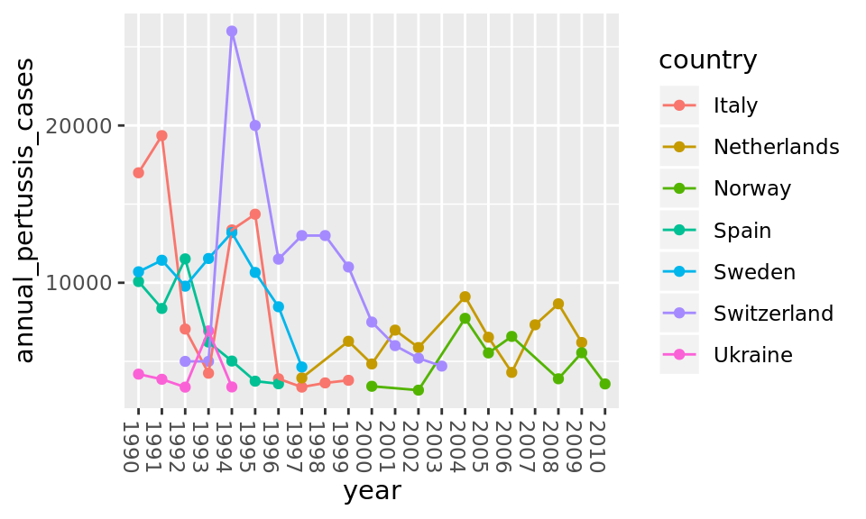

```r
join_filtered %>%
  ggplot(aes(x = year,
             y = annual_pertussis_cases)) +
  geom_point(aes(colour = country)) +
  geom_line(aes(group = country, colour = country)) +
  theme(axis.text.x = element_text(angle = -90, hjust = 1))
```

## `dplyr::arrange()`

## Sorting data with `arrange()`

- Sort(rank) your data ascending or descending
- `{dplyr}` verb to use is `arrange()`,
- In conjunction with the `desc()` function if you want to rank in descending order
- `arrange()` takes one or multiple variable names for which you want to sort

## Example `arrange()`

```r
## ascending
join_filtered %>%
  arrange(annual_pertussis_cases)
```

```
## # A tibble: 61 x 3
##    year  country annual_pertussis_cases
##    <chr> <chr>                    <dbl>
##  1 2002  Norway                    3170
##  2 1992  Ukraine                   3363
##  3 1997  Italy                     3364
##  4 1994  Ukraine                   3374
##  5 2000  Norway                    3417
##  6 2010  Norway                    3565
##  7 1996  Spain                     3577
##  8 1998  Italy                     3632
##  9 1995  Spain                     3741
## 10 1999  Italy                     3797
## # ... with 51 more rows
```

```r
## descending
join_filtered %>%
  arrange(desc(annual_pertussis_cases))
```

```
## # A tibble: 61 x 3
##    year  country     annual_pertussis_cases
##    <chr> <chr>                        <dbl>
##  1 1994  Switzerland                  26000
##  2 1995  Switzerland                  20000
##  3 1991  Italy                        19356
##  4 1990  Italy                        16992
##  5 1995  Italy                        14359
##  6 1994  Italy                        13360
##  7 1994  Sweden                       13187
##  8 1997  Switzerland                  13000
##  9 1998  Switzerland                  13000
## 10 1993  Sweden                       11542
## # ... with 51 more rows
```

Apparently the worst `pertussis` year was 1994 in Switzerland?

## `dplyr::mutate()`

## Changing variables on the basis of a computation (`mutate()`)

Sometimes you want to change a variable by mutation e.g.:

- Change type of the variable
- Compute a new variable using two exisiting ones
- Do a mathmatical transformation (e.g. `log10()` of `log2()`)
- … something else that mutates a variable

You can do two things:

1. Overwrite an existing variable with the newly mutated one
2. Add a newly mutated variable to the existing data

## Example `mutate()`

The annual pertussis cases is reported as an absolulte number per year. Using the population size from the `gapminder` dataset, we can calculate the number of pertussis cases per 100.000 people in a country with `mutate()`

```r
join_new <- join %>%
  dplyr::mutate(incidence =
                  (annual_pertussis_cases/population)*100000) %>%
  select(incidence,
         annual_pertussis_cases,
         country, year) %>%
  arrange(desc(incidence))
join_new
```

```
## # A tibble: 861 x 4
##    incidence annual_pertussis_cases country     year
##        <dbl>                  <dbl> <chr>       <chr>
##  1      374.                  26000 Switzerland 1994
##  2      285.                  20000 Switzerland 1995
##  3      183.                  13000 Switzerland 1997
##  4      183.                  13000 Switzerland 1998
##  5      169.                   7737 Norway      2004
##  6      163.                  11500 Switzerland 1996
##  7      154.                  11000 Switzerland 1999
##  8      150.                  13187 Sweden      1994
##  9      141.                   6587 Norway      2006
## 10      133.                  11432 Sweden      1991
## # ... with 851 more rows
```

## Plotting the cases/100.000

```r
pop_size_corrected <- join_new %>%
  filter(country == "Netherlands" | country == "Norway") %>%
  ggplot(aes(x = year,
             y = incidence)) +
  geom_line(aes(group = country, colour = country)) +
  theme(axis.text.x = element_text(angle = -90, hjust = 1))
```

## Let's see the difference between correcting for population size or not

```r
pop_size_uncorrected <- join %>%
  filter(country == "Netherlands" | country == "Norway") %>%
  ggplot(aes(x = year,
             y = annual_pertussis_cases)) +
  geom_line(aes(group = country, colour = country)) +
  theme(axis.text.x = element_text(angle = -90, hjust = 1))
```

## Plotting two graphs in a panel

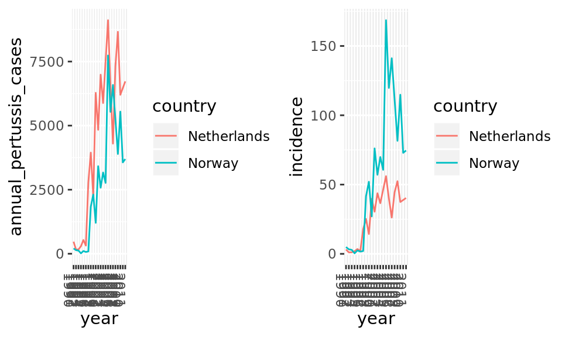

```r
cowplot::plot_grid(pop_size_uncorrected,
                   pop_size_corrected)
```

## **Discuss with you neighbour**

Using `dplyr::mutate()`

- Calculate the log10 of the population in a new variable called `log10_pop`
- Add this new variable to the `join` dataset
- Create a (meaningfull) plot using this new `log10_pop` variable

**please do not scroll ahead**

## **ANSWER**

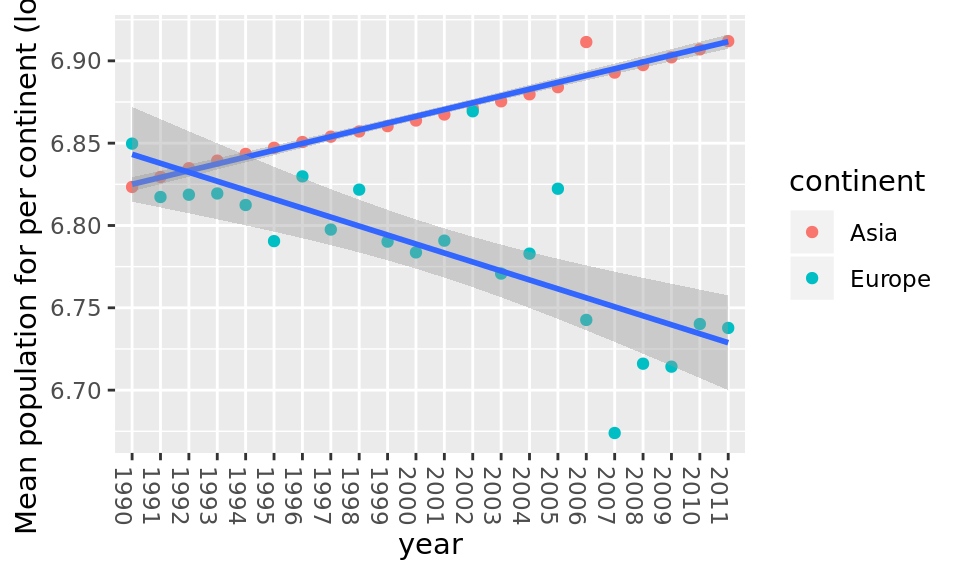

```r
join %>%
  dplyr::mutate(log10_pop = log10(population)) %>%
  group_by(continent, year) %>%
  summarise(mean_pop = mean(log10_pop)) %>%
  ggplot(aes(x = year,
             y = mean_pop)) +
  geom_point(aes(colour = continent)) +
  geom_smooth(aes(group = continent), method = "lm") +
  ylab("Mean population for per continent (log10)") +
  theme(axis.text.x = element_text(angle = -90, hjust = 1))
```

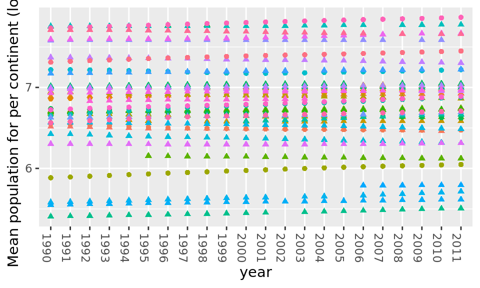

```r
## (without summarize)
join %>%
  dplyr::mutate(log10_pop = log10(population)) %>%
  ggplot(aes(x = year,
             y = log10_pop)) +
  geom_point(aes(colour = country, shape = continent)) +
  ylab("Mean population for per continent (log10)") +
  theme(axis.text.x = element_text(angle = -90, hjust = 1)) +                     theme(legend.position="none")
```

## Summarize data with `dplyr::summarise()`

## Summary data

Summarizing data is an important step in Exploratory Data Analysis. Especially if you have high deminsional data, summarizing might lead you to interesting findings. It can also reveal or raise questions on bias in the data.

## Example `dplyr::summarise()`

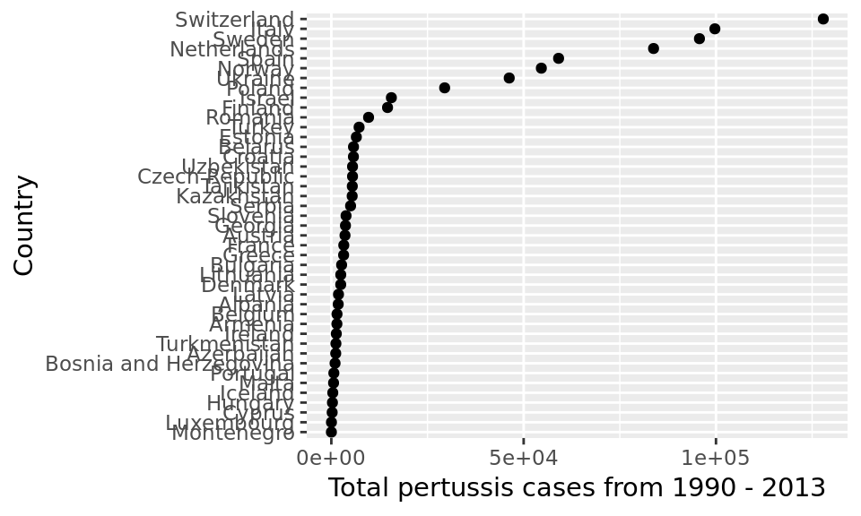

```r
join %>%
  group_by(country) %>%
  summarise(total_pertussis_cases = sum(annual_pertussis_cases)) %>%
  ggplot(aes(x = reorder(as_factor(country), total_pertussis_cases),
             y = total_pertussis_cases)) +
  geom_point() +
  coord_flip() +
  ylab("Total pertussis cases from 1990 - 2013") +
  xlab("Country")
```

Reporting bias?

## **Discuss with your neighbour**

Create a code chuk below that:

- Groups the data by `gdp`, `continent` and `year` (use the `gapminder` dataset)
- Calculate the total population and the total gdp for each continent and each year
- Plot the data in a graph that shows the relationship between year, continent, total gdp per continent and total population per continent.

**TIP** You might want to map population-size to the size of the datapoints

```r
## your answer goes here --->
```

**Please do not scroll ahead**

## **ONE POSSIBLE SOLUTION**

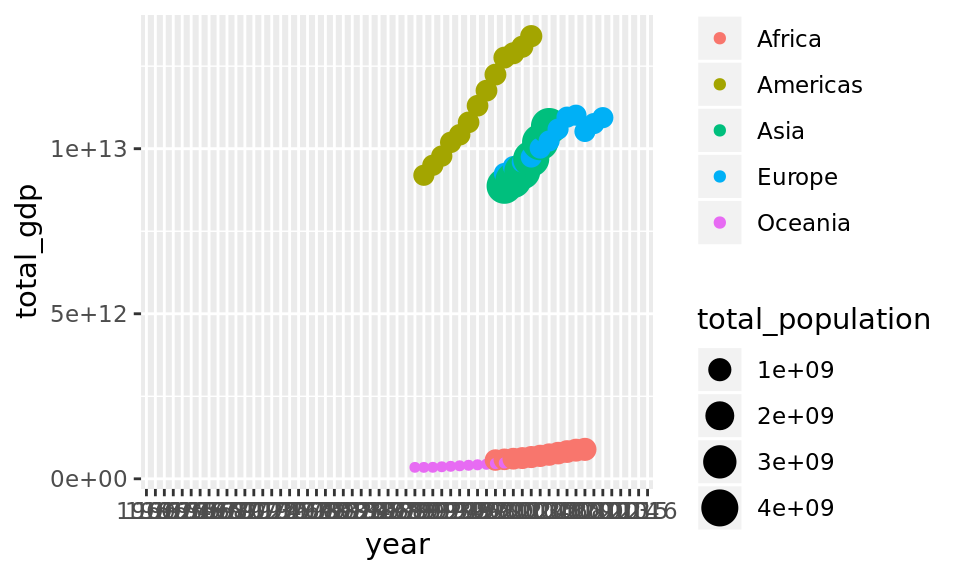

```r
gapminder %>%
  group_by(year, continent) %>%
  summarise(total_population = sum(population),
            total_gdp = sum(gdp)) %>%
    ggplot(aes(x = year,
               y = total_gdp)) +
  geom_point(aes(colour = continent, size = total_population))
```

## ONE MORE, **Discuss with you neighbour**

**Write a code chunk below:**

- Using `{ggplot2}`
- Plot `annual_pertussis_cases` againt `infant_mortality`
- Filter only for "Belarus" and "Netherlands"
- Use all available data for these countries
- Do not scroll ahead
- What do you think is going on with this relationship?
- Try using `colour = year` in your code
- Try using `facet`s

## **ONE POSSIBLE SOLUTION**

```r
names(join)
```

```
##  [1] "country"                "year"
##  [3] "infant_mortality"       "life_expectancy"
##  [5] "fertility"              "population"
##  [7] "gdp"                    "continent"
##  [9] "region"                 "annual_pertussis_cases"
```

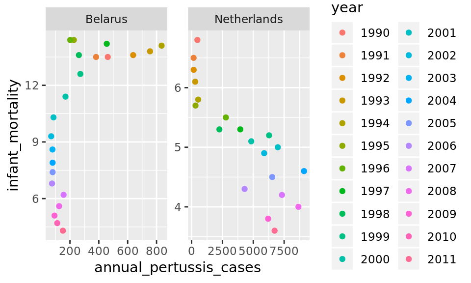

```r
join %>%
  dplyr::filter(country == "Netherlands" |
         country == "Belarus") %>%
    ggplot(aes(x = annual_pertussis_cases,
               y = infant_mortality)) +
      geom_point(aes(colour = year)) +
  facet_wrap(~ country, scales = "free")
```

## Other data sources

As well as data frames, dplyr works with data that is stored in other ways, like data tables, databases and multidimensional arrays.

To see a tutorial: https://db.rstudio.com/dplyr/